# Relational Databases and SQL

## Why you might need to know SQL

- If you want to access data stored on a relational database, you’ll need to know the basics of SQL

## When to build a database

- When data is too big to fit into memory, or when you intend to “grow” a large data base incrementally:
  - growing data in memory is inefficient, so processes like a mass web-scraping need to write results to the disk.
  - memory is still costly, but storage is dirt cheap
- When you have complex data sets with lots of users making changes and a premium on ensuring data integrity.
  - big institutions need centralized data that can handle lots of concurrent users making changes
  - they often need fine-grained control over who sees what and what changes can be made

## Motivation: problems with one big table

## Motivation: problems with one big table

- For the purposes of analysis, we often end up working with one big table. There’s a lot to be said for this! Especially if you’re just analyzing a manageable amount of existing data.
- However: each new semester would mean 3 or 4 new repetitions of a student’s name.

| name | student_id | dob | semester | term_start_date | rank | class | grade |
| --- | --- | --- | --- | --- | --- | --- | --- |
| Spike Vida | 111 | 2004-06-11 | Spring 2024 | 2024-02-01 | FR | GVPT201 | A |
| Spike Vida | 111 | 2004-06-11 | Fall 2024 | 2024-08-01 | FR | SOC425 | B |
| Romi Izzy | 222 | 2009-12-10 | Spring 2024 | 2024-02-01 | FR | MATH199 | C |
| Romi Izzy | 222 | 2009-12-10 | Fall 2024 | 2024-08-01 | FR | BIO101 | A- |
| Elo Aisopos | 333 | 2010-03-13 | Spring 2024 | 2024-02-01 | SO | SOCI326K | P |
| Elo Aisopos | 333 | 2010-03-13 | Fall 2024 | 2024-08-01 | SO | BIO101 | B+ |
| Elo Aisopos | 333 | 2010-03-13 | Spring 2025 | 2025-08-01 | JR | MATH100 | A |
| Jahid Mirjana | 444 | 2011-10-30 | Spring 2024 | 2024-02-01 | SR | BUSI400 | F |
| Jahid Mirjana | 444 | 2011-10-30 | Spring 2025 | 2025-08-01 | SR | BUS401 | W |

## Motivation: problems with one big table

- What happens if I want to add data on a *new* student?
- What happens if I need to alter Jahid Mirjana’s date of birth? What about deleting an incorrect entry?
- What if I want to add information about specific classes?
- What if I try to get a count of the number of freshmen in the Spring 2024 semester?

| name | student_id | dob | semester | term_start_date | rank | class | grade |
| --- | --- | --- | --- | --- | --- | --- | --- |
| Spike Vida | 111 | 2004-06-11 | Spring 2024 | 2024-02-01 | FR | GVPT201 | A |
| Spike Vida | 111 | 2004-06-11 | Fall 2024 | 2024-08-01 | FR | SOC425 | B |
| Romi Izzy | 222 | 2009-12-10 | Spring 2024 | 2024-02-01 | FR | MATH199 | C |
| Romi Izzy | 222 | 2009-12-10 | Fall 2024 | 2024-08-01 | FR | BIO101 | A- |
| Elo Aisopos | 333 | 2010-03-13 | Spring 2024 | 2024-02-01 | SO | SOCI326K | P |
| Elo Aisopos | 333 | 2010-03-13 | Fall 2024 | 2024-08-01 | SO | BIO101 | B+ |
| Elo Aisopos | 333 | 2010-03-13 | Spring 2025 | 2025-08-01 | JR | MATH100 | A |
| Jahid Mirjana | 444 | 2011-10-30 | Spring 2024 | 2024-02-01 | SR | BUSI400 | F |
| Jahid Mirjana | 444 | 2011-10-30 | Spring 2025 | 2025-08-01 | SR | BUS401 | W |

### Relational Data

- Instead of one big table, a relational database uses separate tables that can be linked for later use.
- They’re typically structured with an eye towards minimizing redundancy and the kinds of anomalies we referenced earlier:
  - Each row represents an instance of a single “thing”
  - Each column represents a characteristic of that thing
  - Each cell represents a single value of that characteristic
  - Each table has sufficient information so that we could “join” it with related tables if need.

### Relational Data

| name | student_id | dob | semester | term_start_date | rank | class | grade |
| --- | --- | --- | --- | --- | --- | --- | --- |
| Spike Vida | 111 | 2004-06-11 | Spring 2024 | 2024-02-01 | FR | GVPT201 | A |
| Spike Vida | 111 | 2004-06-11 | Fall 2024 | 2024-08-01 | FR | SOC425 | B |
| Romi Izzy | 222 | 2009-12-10 | Spring 2024 | 2024-02-01 | FR | MATH199 | C |
| Romi Izzy | 222 | 2009-12-10 | Fall 2024 | 2024-08-01 | FR | BIO101 | A- |
| Elo Aisopos | 333 | 2010-03-13 | Spring 2024 | 2024-02-01 | SO | SOCI326K | P |
| Elo Aisopos | 333 | 2010-03-13 | Fall 2024 | 2024-08-01 | SO | BIO101 | B+ |
| Elo Aisopos | 333 | 2010-03-13 | Spring 2025 | 2025-08-01 | JR | MATH100 | A |
| Jahid Mirjana | 444 | 2011-10-30 | Spring 2024 | 2024-02-01 | SR | BUSI400 | F |
| Jahid Mirjana | 444 | 2011-10-30 | Spring 2025 | 2025-08-01 | SR | BUS401 | W |

How can I split this table up in a way that meets the previous criteria?

How many tables do I need?

## Normal Forms

The “normal forms” represent a formalized way of thinking about this kind of question. These are progressively “more normal” as we move through each form.

(as a practical matter, there’s rarely a good reason to go beyond the 3NF)

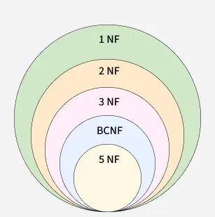

## 1NF

1st Normal Form: all atomic data, with each row representing a discreet unit that can be uniquely identified by a “primary key”

| name | student_id | dob | semester | term_start_date | rank | class | grade |
| --- | --- | --- | --- | --- | --- | --- | --- |
| Spike Vida | 111 | 2004-06-11 | Spring 2024 | 2024-02-01 | FR | GVPT201 | A |
| Spike Vida | 111 | 2004-06-11 | Fall 2024 | 2024-08-01 | FR | SOC425 | B |
| Romi Izzy | 222 | 2009-12-10 | Spring 2024 | 2024-02-01 | FR | MATH199 | C |
| Romi Izzy | 222 | 2009-12-10 | Fall 2024 | 2024-08-01 | FR | BIO101 | A- |
| Elo Aisopos | 333 | 2010-03-13 | Spring 2024 | 2024-02-01 | SO | SOCI326K | P |
| Elo Aisopos | 333 | 2010-03-13 | Fall 2024 | 2024-08-01 | SO | BIO101 | B+ |
| Elo Aisopos | 333 | 2010-03-13 | Spring 2025 | 2025-08-01 | JR | MATH100 | A |
| Jahid Mirjana | 444 | 2011-10-30 | Spring 2024 | 2024-02-01 | SR | BUSI400 | F |
| Jahid Mirjana | 444 | 2011-10-30 | Spring 2025 | 2025-08-01 | SR | BUS401 | W |

(Note: in practice we’ll often assign arbitrary unique IDs to rows to use as a primary key, but for conceptualizing the database think about the **non-arbitrary/external features that would allow us to distinguish a new observation from an existing one.**)

## 2NF

No partial dependencies.

For example:

`{name, dob, semester, class}` uniquely identify each row in this list of grades, but `rank` depends only on `{name, dob, semester}`.

| **name** | **dob** | semester | rank | class | grade |
| --- | --- | --- | --- | --- | --- |
| Spike Vida | 2004-06-11 | Spring 2024 | FR | GVPT201 | A |
| Spike Vida | 2004-06-11 | Fall 2024 | FR | SOC425 | B |
| Romi Izzy | 2009-12-10 | Spring 2024 | FR | MATH199 | C |
| Romi Izzy | 2009-12-10 | Fall 2024 | FR | BIO101 | A- |
| Elo Aisopos | 2010-03-13 | Spring 2024 | SO | SOCI326K | P |
| Elo Aisopos | 2010-03-13 | Fall 2024 | SO | BIO101 | B+ |
| Elo Aisopos | 2010-03-13 | Spring 2025 | JR | MATH100 | A |
| Jahid Mirjana | 2011-10-30 | Spring 2024 | SR | BUSI400 | F |
| Jahid Mirjana | 2011-10-30 | Spring 2025 | SR | BUS401 | W |

## 3NF

No transitive dependencies

For example:

`{name, dob, semester, class}` uniquely identify each row, but `quality_points` depends on grade

| **name** | **dob** | semester | class | grade | quality_points |
| --- | --- | --- | --- | --- | --- |
| Spike Vida | 2004-06-11 | Spring 2024 | GVPT201 | A | 4 |
| Spike Vida | 2004-06-11 | Fall 2024 | SOC425 | B | 3 |
| Romi Izzy | 2009-12-10 | Spring 2024 | MATH199 | C | 2 |
| Romi Izzy | 2009-12-10 | Fall 2024 | BIO101 | A- | 3.5 |
| Elo Aisopos | 2010-03-13 | Spring 2024 | SOCI326K | P | 1 |
| Elo Aisopos | 2010-03-13 | Fall 2024 | BIO101 | B+ | 3 |
| Elo Aisopos | 2010-03-13 | Spring 2025 | MATH100 | A | 4 |
| Jahid Mirjana | 2011-10-30 | Spring 2024 | BUSI400 | F | 0 |
| Jahid Mirjana | 2011-10-30 | Spring 2025 | BUS401 | W | 0 |

## Normalization

- Note here that normalization means sacrificing some ease-of-use for ease of updating/storage. More normalization doesn’t always mean better, and sometimes it makes sense to leave things as is

## ER Diagram

- ER diagrams are a tool for visualizing the schema of a relational database
- Visual tools like https://dbdiagram.io/ allow you to generate SQL code to make a database while you create your ER diagram

## ER Diagram for grades

```
Table student {
  name string
  student_id int
  dob date
}
Table student_term {
  semester string
  student_id int
  rank string
}

Table student_grades {
  student_id int
  semester string
  class string
  grade string
}

Table term_data {
  semester string
  term_start_date date
}
```

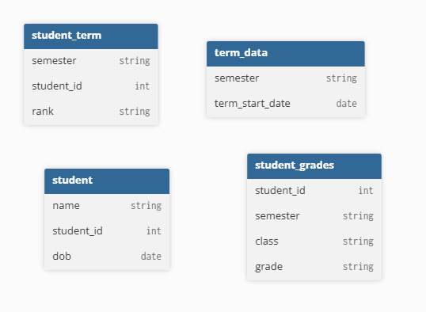

## ER Diagram for grades (with keys)

```
Table student {
  id int [primary key]
  name string
  dob date
}
Table student_term {
  id int [primary key]
  student_id int [ref: > student.id]
  semester_id string [ref: > term_data.id]
  rank string
}

Table term_data {
  id int [primary key]
  semester string
  term_start_date date
}

Table student_grades {
  id int [primary key]
  student_id int [ref: > student.id]
  semester_id string [ref: > term_data.id]
  class string
  grade string
}
```

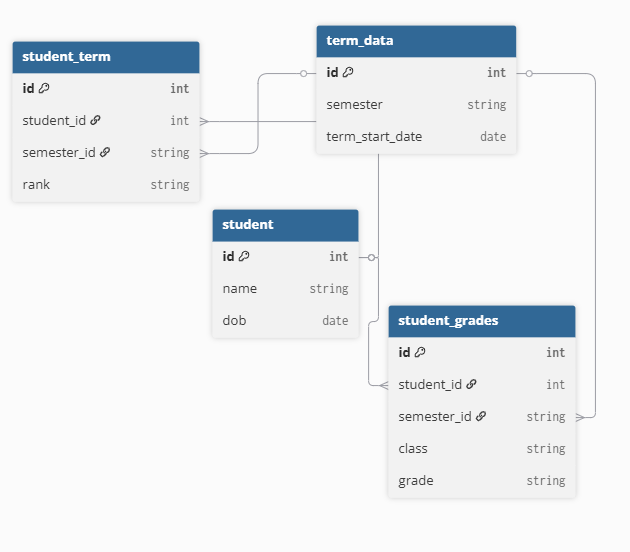

# Election Database

```
// country definition
Table country {
  id INTEGER [primary key]
  country_name_short TEXT
  country_name TEXT
  oecd_accession_date DATE
  eu_accession_date DATE
  iso_numeric INTEGER
}

// election definition
Table election {
  id INTEGER [primary key]
  country_id INTEGER [ref: > country.id]
  election_date DATE
  election_type TEXT
  electorate REAL
  seats_total REAL
  votes_cast REAL
  votes_valid REAL
}

// party definition
Table party {
  id INTEGER [primary key]
  country_id INTEGER [ref: > country.id]
  family_name TEXT
  family_name_short TEXT
  party_name TEXT
  party_name_short TEXT
  party_name_english TEXT
  cmp_id INTEGER
  chess_id INTEGER
}

// party_election_result definition
Table party_election_result {
  id INTEGER [primary key]
  election_id INTEGER [ref: > election.id]
  party_id INTEGER [ref: > party.id]
  alliance_id INTEGER
  votes REAL
  vote_share REAL
  seats REAL
  seat_share REAL
  caretaker BOOL
  cabinet_party BOOL
  prime_minister BOOL
}
```

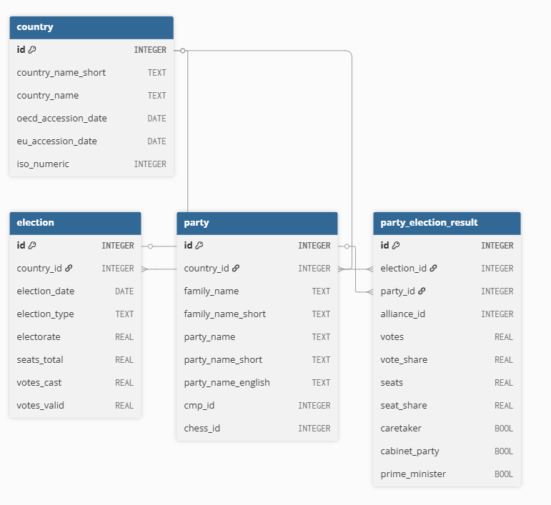

# Election Database

Run the code below to download this version of the ParlGov database.

```r
# install.packages("DBI")
# install.packages("RSQLite)

library(DBI)
download.file('https://github.com/Neilblund/GVPT628Fall2025/raw/refs/heads/main/Data/custom_parlgov.db',
              dest = 'custom_parlgov.db',
              mode='wb'
              )
```

# Basic SQL

## SQL

- Structured Query Language

## Flavors of SQL

- Pedantry point: SQL isn’t technically one thing, and it varies slightly across different RDBMS. The basic features we cover today exist in pretty much any widely used system, but more specialized functions may be specific to a particular SQL flavor.
  - PostgreSQL
  - MySQL
  - T-SQL
  - **SQLIte**
  - Apache Spark SQL

[figure not shown]

## SQL + R

### SQL with DBI

```r
newdb <- dbConnect(RSQLite::SQLite(), "custom_parlgov.db")
```

Use `dbGetQuery` to send a SQL query statement.

```r
election_df <- dbGetQuery(newdb, "SELECT * from election")

election_df|>
  slice_head()
```

| id | country_id | election_date | election_type | electorate | seats_total | votes_cast | votes_valid |
| --- | --- | --- | --- | --- | --- | --- | --- |
| 1 | 11 | 1972-11-25 | Parliamentary election | 1569937 | 87 | 1410240 | 1401152 |

Or get a list of tables in the database:

```r
dbListTables(newdb)
```

```
[1] "Voteshares"            "country"               "election"
[4] "last_election"         "party"                 "party_election_result"
```

### SQL with DBI

One useful advantage of this setup is that you can use R variables inside of your SQL queries:

```r
library(glue)

newdb <- dbConnect(RSQLite::SQLite(), "custom_parlgov.db")

last_year<-Sys.Date()-1095


election_df <- dbGetQuery(newdb, glue("SELECT * from election where election_date >= '{last_year}'"))

election_df
```

| id | country_id | election_date | election_type | electorate | seats_total | votes_cast | votes_valid |
| --- | --- | --- | --- | --- | --- | --- | --- |
| 1118 | 75 | 2023-03-05 | Parliamentary election | 966129 | 101 | 613801 | 610299 |
| 1119 | 67 | 2023-04-02 | Parliamentary election | 4277487 | 200 | 3110038 | 3095604 |
| 1120 | 10 | 2023-04-02 | Parliamentary election | 6594593 | 240 | 2683606 | 2638024 |
| 1121 | 20 | 2023-05-14 | Parliamentary election | 64190651 | 600 | 55836055 | 54442419 |
| 1122 | 41 | 2023-05-21 | Parliamentary election | 9946082 | 300 | 6061098 | 5902850 |
| 1123 | 41 | 2023-06-25 | Parliamentary election | 9813595 | 300 | 5273699 | 5215207 |

Finish by running `dbDisconnect` to close your connection to the database.

```r
dbDisconnect(newdb)
```

### SQL in a markdown file

First, you can connect to an external database using functions from the `DBI` package.

````
```{r}
library(DBI)
newdb <- dbConnect(RSQLite::SQLite(), "custom_parlgov.db")

```
````

Once you’ve done this, you can create a SQL code chunk in a markdown file like this:

````
```{sql, connection = newdb}
SELECT * from election

```
````

If you want to be able to access the SQL output from R, you can add an `output.var` option to the chunk header. The output from your SQL chunk will then be available in R with whatever variable name you specify:

````
```{sql, connection = newdb, output.var = 'elections_df'}
SELECT * from election

```
````

## Basic SQL Queries

- The simple scenario: how do I get stuff out of my SQL database?
- Note: you can do many of these things in R *after* loading the data, so how much SQL you use is partly about preference.

### Basic query

- **SELECT** one or more columns (* is a wild card that retrieves all columns. Use at your own risk!)
- **FROM** specifies a table in the database
- These two are the only required parts of an SQL query.

```sql
SELECT id, election_date, votes_cast
FROM election
```

Displaying records 1 - 10

| id | election_date | votes_cast |
| --- | --- | --- |
| 1 | 1972-11-25 | 1410240 |
| 2 | 1999-06-13 | 6650015 |
| 3 | 2005-09-12 | 2649520 |
| 4 | 2007-01-01 | NA |
| 5 | 2009-06-07 | 3568943 |
| 6 | 1977-06-16 | 1616770 |
| 8 | 1971-06-14 | 168913 |
| 10 | 1984-06-17 | 6424168 |
| 11 | 1953-02-22 | 4395519 |
| 13 | 1995-01-01 | NA |

### WHERE

- The **WHERE** clause will filter rows based on one or more conditions

```sql
SELECT *
FROM election
WHERE election_date >='2023-01-01'
```

6 records

| id | country_id | election_date | election_type | electorate | seats_total | votes_cast | votes_valid |
| --- | --- | --- | --- | --- | --- | --- | --- |
| 1118 | 75 | 2023-03-05 | Parliamentary election | 966129 | 101 | 613801 | 610299 |
| 1119 | 67 | 2023-04-02 | Parliamentary election | 4277487 | 200 | 3110038 | 3095604 |
| 1120 | 10 | 2023-04-02 | Parliamentary election | 6594593 | 240 | 2683606 | 2638024 |
| 1121 | 20 | 2023-05-14 | Parliamentary election | 64190651 | 600 | 55836055 | 54442419 |
| 1122 | 41 | 2023-05-21 | Parliamentary election | 9946082 | 300 | 6061098 | 5902850 |
| 1123 | 41 | 2023-06-25 | Parliamentary election | 9813595 | 300 | 5273699 | 5215207 |

### WHERE

- `AND`, `OR` chain together logical expressions.
- `=`, `>=`, `<=` have the same role as their mathemtical counterparts
- `IN` operates similarly to the `%in%` operator in R: it returns rows that match any value in a list

```sql
SELECT election_date, country_id, seats_total, votes_cast
FROM election
WHERE
  election_date >='2010-01-01'
  AND country_id IN (1, 37)
  AND election_type ='Parliamentary election'
```

7 records

| election_date | country_id | seats_total | votes_cast |
| --- | --- | --- | --- |
| 2010-06-12 | 1 | 150 | 2566779 |
| 2011-02-25 | 37 | 166 | 2243176 |
| 2012-03-10 | 1 | 150 | 2596443 |
| 2016-02-26 | 37 | 158 | NA |
| 2016-03-06 | 1 | 150 | 2648184 |
| 2020-02-08 | 37 | 160 | 2201192 |
| 2020-02-29 | 1 | 150 | 2916840 |

### WHERE with a subquery

- We can use `WHERE` clauses to query another table.
- This code would retrieve elections for all non-EU countries.

```sql
SELECT election_date, country_id, seats_total, votes_cast
FROM election
WHERE
  country_id IN (SELECT id from country where eu_accession_date is null)
  AND election_type = "Parliamentary election"
```

Displaying records 1 - 10

| election_date | country_id | seats_total | votes_cast |
| --- | --- | --- | --- |
| 1972-11-25 | 11 | 87 | 1410240 |
| 2005-09-12 | 9 | 169 | 2649520 |
| 1951-10-28 | 40 | 196 | 986937 |
| 1990-02-18 | 5 | 512 | 66215906 |
| 1955-10-30 | 40 | 196 | 998881 |
| 1946-06-30 | 56 | 52 | 67896 |
| 2009-04-25 | 56 | 63 | 193934 |
| 1976-12-05 | 5 | 511 | 57231992 |
| 1984-07-14 | 11 | 95 | 1978798 |
| 1993-07-18 | 5 | 511 | 63547819 |

### ORDER BY

- `ORDER BY` sorts results by a variable. `ASC` means “ascending order”, `DESC` means “descending order”
- You can sort by multiple columns (similar to `arrange` in `dplyr`)

```sql
SELECT election_date, country_id, seats_total, votes_cast
FROM election
WHERE
  election_date >='2010-01-01'
  AND  election_type = "Parliamentary election"
ORDER BY
  votes_cast DESC
```

Displaying records 1 - 10

| election_date | country_id | seats_total | votes_cast |
| --- | --- | --- | --- |
| 2012-12-16 | 5 | 480 | 61662947 |
| 2021-10-31 | 5 | 176 | 58575222 |
| 2017-10-22 | 5 | 465 | 56950957 |
| 2023-05-14 | 20 | 600 | 55836055 |
| 2014-12-14 | 5 | 475 | 54735787 |
| 2018-06-24 | 20 | 600 | 51183729 |
| 2015-11-01 | 20 | 550 | 48537695 |
| 2015-06-07 | 20 | 550 | 47507467 |
| 2017-09-24 | 54 | 709 | 46976341 |
| 2021-09-26 | 54 | 736 | 46854508 |

### LIMIT

- You can use a `LIMIT` clause to only retrieve a fixed number of rows.
- This is a good way to peek at some data without accidentally loading everything

```sql
SELECT id, election_date, votes_cast
FROM election
WHERE election_date >='2020-01-01'
LIMIT 1
;
```

1 records

| id | election_date | votes_cast |
| --- | --- | --- |
| 1088 | 2020-02-08 | 2201192 |

### Try it out

- get the `election_id` and `votes_cast` for the 5 most recent elections in the database
- get all variables for all elections where `seats_total` is under 100
- get the list of all parties where the `party_family` is `conservative`
- get a list of elections ordered by voter turnout (you can do simple row-wise calculations inside the select statement like `SELECT NUMERATOR/DENOMINATOR FROM TABLE)`

## Aggregations and groups

### COUNT

- `COUNT` counts values
- `COUNT(DISTINCT(var))` counts only unique values
- Operations like `SUM` or `AVG` do pretty much what you would expect
- The `WHERE` clause is evaluated **before** the aggregation.

```sql
SELECT COUNT(*),
       SUM(votes_cast),
       COUNT(DISTINCT(country_id))
FROM election
WHERE election_date >='2020-01-01'
;
```

1 records

| COUNT(*) | SUM(votes_cast) | COUNT(DISTINCT(country_id)) |
| --- | --- | --- |
| 36 | 347659185 | 29 |

### ALIASING

- Aliasing allows you to assign new names to a column

```sql
SELECT
  COUNT(*) total_rows,
  SUM(votes_cast) all_votes,
  COUNT(DISTINCT(country_id)) n_countries
FROM election
WHERE election_date >='2020-01-01'
;
```

1 records

| total_rows | all_votes | n_countries |
| --- | --- | --- |
| 36 | 347659185 | 29 |

### GROUPING

- **GROUP BY** can be used to specify a grouping variable to perform aggregate calculations over.
- For instance, this code would count the number of elections in each country since 2020.

```sql
SELECT country_id,  COUNT(*) as country_elections
FROM election
WHERE election_date >='2020-01-01'
GROUP BY
country_id
ORDER BY country_elections DESC
LIMIT 5
;
```

5 records

| country_id | country_elections |
| --- | --- |
| 10 | 5 |
| 34 | 3 |
| 41 | 2 |
| 75 | 1 |
| 68 | 1 |

### HAVING

- `HAVING` performs filtering on the aggregated results. (unlike `WHERE` which applies *before* aggregation)

```sql
SELECT country_id, COUNT(*) as country_elections
FROM election
WHERE election_date >='2020-01-01'
GROUP BY
country_id
HAVING country_elections>1
ORDER BY country_elections DESC
;
```

3 records

| country_id | country_elections |
| --- | --- |
| 10 | 5 |
| 34 | 3 |
| 41 | 2 |

### Try it out

- Get the total number of parties associated with each party family
- Find the highest turnout in a Parliamentary election for each country
- Calculate the effective number of electoral parties for each parliamentary election.
- Get a list of elections where the effective number of electoral parties was greater than 3.

## Joins

- join statements can be used to get columns from a related table in the database.
- the `join` part specifies what table I’m joining from.
- the `on` statement specifies how the join should be performed.
- Because some column names appear in both tables, I use the `tablename.columname` notation in the select statement to avoid any ambiguities in which column I’m referencing.

```sql
SELECT country.country_name, election.election_date, election.votes_cast
from election
inner join country
on election.country_id = country.id;
```

Displaying records 1 - 10

| country_name | election_date | votes_cast |
| --- | --- | --- |
| New Zealand | 1972-11-25 | 1410240 |
| Belgium | 1999-06-13 | 6650015 |
| Norway | 2005-09-12 | 2649520 |
| Romania | 2007-01-01 | NA |
| Portugal | 2009-06-07 | 3568943 |
| Ireland | 1977-06-16 | 1616770 |
| Malta | 1971-06-14 | 168913 |
| Belgium | 1984-06-17 | 6424168 |
| Austria | 1953-02-22 | 4395519 |
| Austria | 1995-01-01 | NA |

### JOIN TYPES

- `INNER JOIN`: returns rows that are matching in both tables
- `LEFT` join: returns all rows in the left table and matching rows in the right table.
- `RIGHT` join: returns all rows in the right table and matching rows in the left table.

### Multiple JOINS

You can combine multiple joins in a single statement. For instance, this statement would include variables from three of the four tables in the database:

```sql
SELECT
  party_election_result.party_id,
  party.party_name_short,
  party.family_name_short,
  party_election_result.election_id,
  election.election_date,
  MAX(party_election_result.vote_share) as best_voteshare
FROM party_election_result
JOIN election ON party_election_result.election_id = election.id
JOIN party ON party.id = party_election_result.party_id
WHERE election.election_type = 'Parliamentary election'
GROUP BY party_id
```

Displaying records 1 - 10

| party_id | party_name_short | family_name_short | election_id | election_date | best_voteshare |
| --- | --- | --- | --- | --- | --- |
| 2 | TOP09 | con | 599 | 2010-05-29 | 16.70 |
| 3 | KNP | chr | 543 | 1952-06-25 | 2.71 |
| 4 | PNP | con | 554 | 2005-09-11 | 1.74 |
| 5 | PU\|PC | con | 1093 | 2020-12-06 | 1.01 |
| 6 | NO | right | 339 | 2001-05-27 | 3.00 |
| 11 | APU | com | 248 | 1979-12-02 | 19.33 |
| 15 | KSII | spec | 681 | 2001-06-18 | 3.44 |
| 16 | SLS | chr | 338 | 1996-11-10 | 19.38 |
| 18 | SoPr | soc | 211 | 1991-10-27 | 2.10 |
| 19 | HSD-SMS | spec | 63 | 1990-06-09 | 10.03 |

### WITH and CTE

- A `WITH` clause can be used to create a temporary table that can be queried with a new `SELECT` statement.
- Its a good way to break up really complicated queries, and can be faster than comparable alternatives in some scenarios.

```sql
WITH last_election as (
  SELECT country_id,
  MAX(election_date) as last_election_date
  FROM election where
  election_type = 'Parliamentary election'
  GROUP BY(country_id)

)
SELECT id, last_election_date, last_election.country_id, election_type, electorate, seats_total, votes_cast, votes_valid from election
RIGHT JOIN last_election on last_election_date = election_date AND election.country_id = last_election.country_id
where election_type = 'Parliamentary election'
```

Displaying records 1 - 10

| id | last_election_date | country_id | election_type | electorate | seats_total | votes_cast | votes_valid |
| --- | --- | --- | --- | --- | --- | --- | --- |
| 1010 | 2017-06-03 | 72 | Parliamentary election | 341856 | 67 | 314696 | 310665 |
| 1043 | 2018-10-14 | 7 | Parliamentary election | 259887 | 60 | 233014 | 216177 |
| 1048 | 2019-05-26 | 64 | Parliamentary election | 8167709 | 150 | 7218633 | 6780538 |
| 1080 | 2019-09-29 | 59 | Parliamentary election | 6396812 | 183 | 4835469 | 4777246 |
| 1082 | 2019-10-13 | 74 | Parliamentary election | 30253556 | 460 | 18682535 | 18678457 |
| 1083 | 2019-10-20 | 40 | Parliamentary election | 5459218 | 200 | 2462581 | 2424202 |
| 1085 | 2019-11-10 | 27 | Parliamentary election | 37001379 | 350 | 24507715 | 24258228 |
| 1086 | 2019-12-12 | 44 | Parliamentary election | 47587254 | 650 | 32014065 | NA |
| 1088 | 2020-02-08 | 37 | Parliamentary election | 3498526 | 160 | 2201192 | 2183489 |
| 1089 | 2020-02-29 | 1 | Parliamentary election | 4432419 | 150 | 2916840 | 2881511 |

### Try it out

- Add party name and EU join date to the `party_election_result` table.
- Create a table with `country_name`, `election_date`, and the effective number of political parties for each election.

```sql
WITH voteshares as(
SELECT party_id,
      election_id,
      election_date,
      country_id,
      vote_share,
      election.votes_cast,
      election.seats_total,
      vote_share as voteshare,
      (seats/seats_total) * 100 seatshare,
      votes
FROM party_election_result
INNER JOIN election ON party_election_result.election_id = election.id
WHERE election.election_type = 'Parliamentary election'
AND election.election_date >'2000-01-01'
)
SELECT country_name country_id, election_id, election_date,
       SQRT(.5 * SUM(POWER(voteshare - seatshare, 2))) as gallagher_index from voteshares
join country
on country_id = country.id
group by election_id
ORDER BY election_id
```

Displaying records 1 - 10

| country_id | election_id | election_date | gallagher_index |
| --- | --- | --- | --- |
| Norway | 3 | 2005-09-12 | 2.5926516 |
| Iceland | 36 | 2009-04-25 | 2.5265898 |
| Czech Republic | 50 | 2006-06-03 | 5.6489734 |
| Latvia | 52 | 2006-10-07 | 4.8113979 |
| Lithuania | 59 | 2000-10-08 | 10.8595471 |
| Netherlands | 74 | 2002-05-15 | 0.9234507 |
| Bulgaria | 79 | 2009-07-05 | 6.9839976 |
| Slovenia | 80 | 2004-10-03 | 4.8667440 |
| Estonia | 83 | 2007-03-04 | 3.3982005 |
| Germany | 93 | 2009-09-27 | 3.3483139 |

## Views

- Database “views” allow you to create virtual tables that store results from an SQL query.
- Views store the query, not the data, so we can put the big redundant elections table in a view and it will still have a tiny footprint.
- For instance: a campaign might want a view that shows only upcoming gubernatorial elections, a risk management firm might want a table with aggregate counts of riots in the last week, or a GVPT advisor might need to be able to see records for GVPT students and have all others hidden.

### VIEWS

To create a view, you can add `CREATE VIEW [VIEWNAME] as` in front of a SQL query:

```sql
CREATE VIEW last_election as
WITH last_election as (
  SELECT country_id,
  MAX(election_date) as last_election_date
  FROM election where
  election_type = 'Parliamentary election'
  GROUP BY(country_id)

)
SELECT id, last_election_date, last_election.country_id, election_type, electorate, seats_total, votes_cast, votes_valid from election
RIGHT JOIN last_election on last_election_date = election_date AND election.country_id = last_election.country_id
where election_type = 'Parliamentary election'
```

### Views

Once you’ve done this, you can query the view like another SQL table:

```sql
SELECT * from last_election limit 1
```